# Describing and Visualizing Categorical Variables

## Introduction

- At ZPD, Deputy Chief Okonkwo drops by again: *“Numbers are great, but I also need to know who’s where. Break the recruits down by group for me.”*
- In the last lecture, we described **continuous** variables: things measured on a number line, like a score or an income.
- Today we will describe **categorical** variables: things that sort recruits into *groups* rather than measuring them on a scale.
  - There is no “average” district the way there is an average exam score.

## `R` Set Up

```r
library(tidyverse)
library(ssstats)
zootopia <- read_csv("https://raw.githubusercontent.com/samanthaseals/SDSI/refs/heads/main/files/data/lectures/1-zootopia.csv")
```

| resident_name | department | district | academy_status |
| --- | --- | --- | --- |
| Sable Jones | Desk | Rainforest District | Fail |
| Kevin Frostwhisker | Patrol | Downtown | Fail |
| Jasper Duskrunner | Patrol | Sahara Square | Pass |
| Greta Smith | Desk | Tundratown | Pass |
| Otto Meadowsly | Patrol | Downtown | Pass |

## Describing Categorical Data

Categorical Data

For **categorical variables**, we describe data by counting how many observations fall into each category, not by averaging values.

- We have two main tools for describing a categorical variable:
  - Frequency
  - Relative frequency (proportion)

## Frequency

Frequency

The **frequency** of a category is simply a count: how many observations fall into that group.

- Frequencies answer the question: *how many?*
  - How many recruits are in Patrol?
  - How many recruits work in Sahara Square?
- Frequencies are useful, but interpreting them depends on the size of the dataset.

## Relative Frequency

Relative Frequency

The **relative frequency** (proportion), is the frequency divided by the total number of observations.

$$\text{proportion} = \frac{\text{count in category}}{\text{total number of observations}}$$

- Proportions answer the question: *what share?*
  - What share of recruits are in Patrol?
  - What share of recruits work in Sahara Square?
- Because proportions are standardized, they allow us to compare groups of very different sizes.

## Describing the Data (`R`)

- We will use the `n_pct()` function from the `ssstats` package to describe the frequency and proportion of our categorical data.

```r
dataset_name |>
  n_pct(variable)
```

**1**

`dataset_name` is the name of the dataset you are working with.

**2**

`n_pct()` returns the count (n) and percentage for each category of the variable you list.

- Just like `mean_median()`, we can use `group_by()` to get counts and percentages broken down by another categorical variable.
- Note: if you need help getting started in R, please see the R module on Canvas.

## Describing the Data

- For illustrative purposes, we will describe the `department` variable in the `zootopia` dataset.

```r
zootopia |>
  n_pct(department)
```

| department | n (pct) |
| --- | --- |
| Desk | 12 (40.0%) |
| Patrol | 18 (60.0%) |

- This tells us that of the 30 recruits,
  - 18 (60.0%) are in Patrol,
  - 12 (40.0%) are on Desk duty.

## Bar Graphs

Bar chart

A **bar chart** shows one bar per category, with the height of the bar equal to the number (or percentage) of observations in that category.

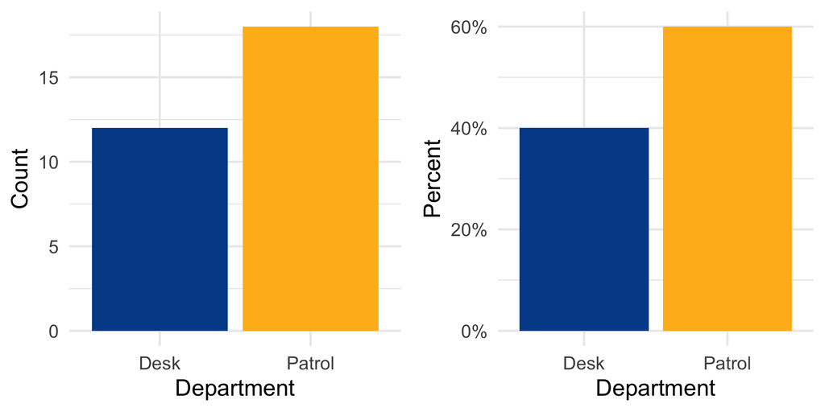

## Bar Graphs (`R`)

Bar chart

A **bar chart** shows one bar per category, with the height of the bar equal to the number (or percentage) of observations in that category.

```r
dataset_name |>
  ggplot(aes(x = category_name)) +
  geom_bar()
```

**1**

`dataset_name` is the name of the dataset you are working with.

**2**

`ggplot()` is the function that creates a plot. The `aes()` function inside it tells R which variable to plot.

**3**

`geom_bar()` counts the observations in each category and draws a bar for each — you don’t need to calculate the counts yourself.

- Sometimes we’d rather show the *share* of recruits in each category instead of the raw count.

```r
dataset_name |>
  ggplot(aes(x = category_name,
             y = after_stat(count) / sum(after_stat(count)))) +
  geom_bar() +
  scale_y_continuous(labels = scales::percent)
```

**1**

`dataset_name` is the name of the dataset you are working with.

**2**

`after_stat(count) / sum(after_stat(count))` converts the raw counts into a proportion of the total.

**3**

`geom_bar()` creates a bar graph.

**4**

`scale_y_continuous(labels = scales::percent)` relabels the y-axis as a percentage instead of a decimal.

## Contingency Tables

Contingency Table

A **two-way table** shows how two categorical variables relate to one another, by counting observations at every combination of categories.

- So far we’ve described one categorical variable at a time.
- Just like a scatterplot let us compare two continuous variables, a contingency table lets us compare two categorical variables.
  - Is department evenly split across every district, or do some districts lean more Patrol or more Desk?

## Contingency Tables (`R`)

- We can construct a contingency table using `n_pct()`.

```r
dataset_name |>
  n_pct(row_variable, column_variable)
```

**1**

`dataset_name` is the name of the dataset you are working with.

**2**

`n_pct()` constructs an R x C contingency table.

- Note that `n_pct()` automatically returns the *column* percentage.

## Example 1

- Let’s describe the characteristics of the recruits in the `zootopia` dataset.
  - Department
  - District
  - Academy status

## Example 1

- Constructing the frequency distribution for department,

```r
zootopia %>% n_pct(department)
```

| department | n (pct) |
| --- | --- |
| Desk | 12 (40.0%) |
| Patrol | 18 (60.0%) |

## Example 1

- Constructing the frequency distribution for district,

```r
zootopia %>% n_pct(district)
```

| district | n (pct) |
| --- | --- |
| Downtown | 8 (26.7%) |
| Rainforest District | 7 (23.3%) |
| Sahara Square | 9 (30.0%) |
| Tundratown | 6 (20.0%) |

## Example 1

- Constructing the frequency distribution for academy status,

```r
zootopia %>% n_pct(academy_status)
```

| academy_status | n (pct) |
| --- | --- |
| Fail | 5 (16.7%) |
| Pass | 25 (83.3%) |

## Example 1

- Constructing contingency tables,

```r
zootopia %>% n_pct(district, department)
```

| district | Desk | Patrol |
| --- | --- | --- |
| Downtown | 2 (16.7%) | 6 (33.3%) |
| Rainforest District | 3 (25.0%) | 4 (22.2%) |
| Sahara Square | 3 (25.0%) | 6 (33.3%) |
| Tundratown | 4 (33.3%) | 2 (11.1%) |

## Example 1

- Constructing contingency tables,

```r
zootopia %>% n_pct(district, academy_status)
```

| district | Fail | Pass |
| --- | --- | --- |
| Downtown | 1 (20.0%) | 7 (28.0%) |
| Rainforest District | 3 (60.0%) | 4 (16.0%) |
| Sahara Square | 1 (20.0%) | 8 (32.0%) |
| Tundratown | 0 (0.0%) | 6 (24.0%) |

## Example 1

- Constructing contingency tables,

```r
zootopia %>% n_pct(department, academy_status)
```

| department | Fail | Pass |
| --- | --- | --- |
| Desk | 3 (60.0%) | 9 (36.0%) |
| Patrol | 2 (40.0%) | 16 (64.0%) |

## Example 1

- Looking at this graphically,

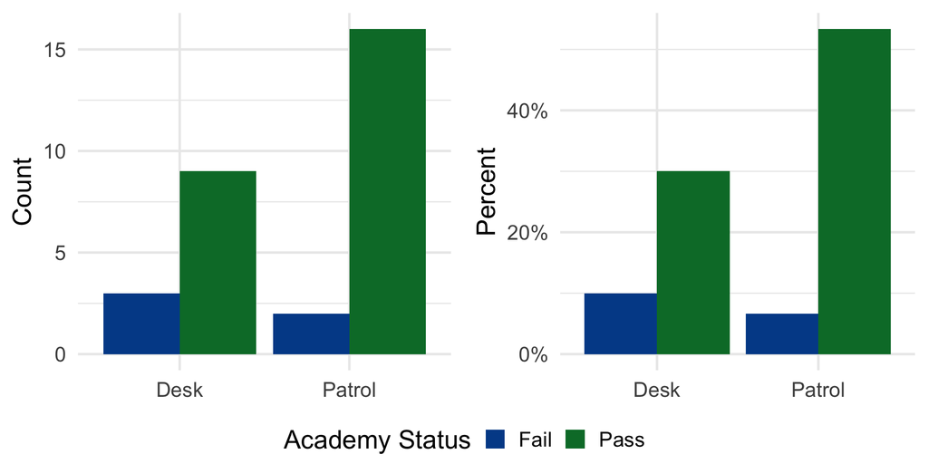

## Wrap Up

- We have covered basics for describing and visualizing categorical variables.
  - Frequencies and proportions
    - Contingency tables
  - Bar graphs